# Multiple responses are for the birds

Thomas Lumley

02/09/2019

The `rimu` package handles multiple-response data, a generalisation of factor data. With factor data, there is a defined set of categories and each observation comes from one category. With multiple-reponse data, there is a defined set of categories, but each observation could come from multiple categories. We provide two classes: `mr` for multiple-response presence/absence data, and `ms` for scored or ranked multiple-responses where each category gets a non-zero score or rank.

The `birds` dataset is a small subset of data from the Great Backyard Bird Count, in the US and Canada. We have counts of 12 birds by US county and Canadian province. The twelve birds are

```r
data(birds)
names(birds)[1:12]
```

```
##  [1] "Phalaenoptilus nuttallii"      "Fregata magnificens"
##  [3] "Melanerpes lewis"              "Melospiza georgiana"
##  [5] "Rallus limicola"               "Myioborus pictus"
##  [7] "Poecile gambeli"               "Aythya collaris"
##  [9] "Xanthocephalus xanthocephalus" "Gracula religiosa"
## [11] "Icterus parisorum"             "Coccyzus erythropthalmus"
```

There's a thirteenth column giving the location name.

These birds are perhaps more familiar as

- Common poorwill, *Phalaenoptilus nuttallii*
- Frigatebird *Fregata magnificens*
- Lewis's woodpecker *Melanerpes lewis*
- Swamp sparrow *Melospiza georgiana*
- Virginia rail *Rallus limicola*
- Painted redstart *Myioborus pictus*
- Mountain chickadee *Poecile gambeli*
- Ring-necked duck *Aythya collaris*
- Yellowheaded blackbird *Xanthocephalus xanthocephalus*
- Common hill myna *Gracula religiosa*
- Scott's oriole *Icterus parisorum*
- Black-billed cuckoo *Coccyzus erythropthalmus*

First, let's put them into the data structures

```r
bird_count <- as.ms(birds[,-13],na.rm=TRUE)
bird_presence <- as.mr(bird_count)
```

The bird counts will print like a sparse matrix

```r
head(bird_count)
```

```
##      Phalaenoptilus nuttallii Fregata magnificens Melanerpes lewis
## [1,] .                        .                   .
## [2,] .                        .                   .
## [3,] .                        .                   .
## [4,] .                        .                   .
## [5,] .                        .                   .
## [6,] .                        .                   .
##      Melospiza georgiana Rallus limicola Myioborus pictus Poecile gambeli
## [1,] .                   .               .                .
## [2,] .                   .               .                .
## [3,] 5                   .               .                .
## [4,] .                   .               .                30
## [5,] .                   .               .                .
## [6,] 1                   .               .                .
##      Aythya collaris Xanthocephalus xanthocephalus Gracula religiosa
## [1,] .               .                             .
## [2,] 1               .                             .
## [3,] 4               .                             .
## [4,] 10              .                             .
## [5,] .               .                             .
## [6,] 1               .                             .
##      Icterus parisorum Coccyzus erythropthalmus
## [1,] .                 .
## [2,] .                 .
## [3,] .                 .
## [4,] .                 .
## [5,] .                 .
## [6,] .                 .
```

but the bird presence/absence data has a more compact character form

```r
head(bird_presence)
```

```
## [1] ""                                    "Aythya collaris"
## [3] "Melospiza georgiana+Aythya collaris" "Poecile gambeli+Aythya collaris"
## [5] ""                                    "Melospiza georgiana+Aythya collaris"
```

What birds are most often present?

```r
mtable(bird_presence)
```

```
##  Phalaenoptilus nuttallii Fregata magnificens Melanerpes lewis
##                         9                  16               87
##  Melospiza georgiana Rallus limicola Myioborus pictus Poecile gambeli
##                  876             121                4             317
##  Aythya collaris Xanthocephalus xanthocephalus Gracula religiosa
##             1090                            80                 1
##  Icterus parisorum Coccyzus erythropthalmus
##                  8                        1
```

And what birds tend to go together? We can draw an upset chart

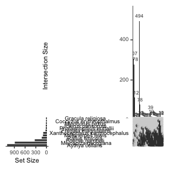

```r
plot(bird_presence,nsets=12)
```

That's all a bit clumsy because of the long names,but you can see, for example, that the swamp sparrow and ring-necked duck tend to co-occur. Let's recode to shorter names.

```r
bird_presence<-mr_recode(bird_presence,
  poorwill="Phalaenoptilus nuttallii",
  frigatebird="Fregata magnificens",
  woodpecker ="Melanerpes lewis",
  sparrow="Melospiza georgiana",
  rail="Rallus limicola",
  redstart="Myioborus pictus",
  chickadee="Poecile gambeli",
  duck="Aythya collaris",
  yellowhead="Xanthocephalus xanthocephalus",
  myna="Dracula religiosa",
  oriole="Icterus parisorum",
  cuckoo="Coccyzus erythropthalmus")
```

```
## Error in mr_recode.default(bird_presence, poorwill = "Phalaenoptilus nuttallii", : non-existent levels Dracula religiosa
```

Oops.

```r
bird_presence<-mr_recode(bird_presence,
  poorwill="Phalaenoptilus nuttallii",
  frigatebird="Fregata magnificens",
  woodpecker ="Melanerpes lewis",
  sparrow="Melospiza georgiana",
  rail="Rallus limicola",
  redstart="Myioborus pictus",
  chickadee="Poecile gambeli",
  duck="Aythya collaris",
  yellowhead="Xanthocephalus xanthocephalus",
  myna="Gracula religiosa",
  oriole="Icterus parisorum",
  cuckoo="Coccyzus erythropthalmus")
```

Now try again:

```r
mtable(bird_presence)
```

```
##  poorwill frigatebird woodpecker sparrow rail redstart chickadee duck
##         9          16         87     876  121        4       317 1090
##  yellowhead myna oriole cuckoo
##          80    1      8      1
```

```r
mtable(bird_presence,bird_presence)
```

```
##             poorwill frigatebird woodpecker sparrow rail redstart chickadee
## poorwill           9           0          2       0    3        0         5
## frigatebird        0          16          0      12    8        0         0
## woodpecker         2           0         87      13   29        3        72
## sparrow            0          12         13     876   72        4        34
## rail               3           8         29      72  121        4        52
## redstart           0           0          3       4    4        4         3
## chickadee          5           0         72      34   52        3       317
## duck               8          13         70     593  114        4       188
## yellowhead         2           3         27      22   22        3        43
## myna               0           1          0       1    1        0         0
## oriole             0           0          4       5    4        3         4
## cuckoo             0           0          0       1    0        0         0
##             duck yellowhead myna oriole cuckoo
## poorwill       8          2    0      0      0
## frigatebird   13          3    1      0      0
## woodpecker    70         27    0      4      0
## sparrow      593         22    1      5      1
## rail         114         22    1      4      0
## redstart       4          3    0      3      0
## chickadee    188         43    0      4      0
## duck        1090         73    1      7      1
## yellowhead    73         80    0      5      0
## myna           1          0    1      0      0
## oriole         7          5    0      8      0
## cuckoo         1          0    0      0      1
```

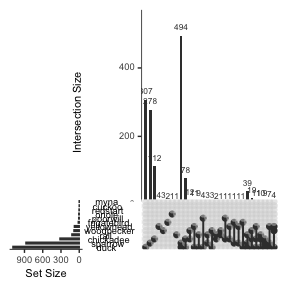

```r
plot(bird_presence, nsets=12,nint=30)
```

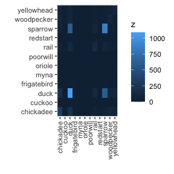

```r
image(bird_presence)
```

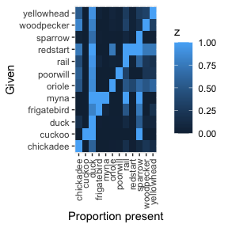

```r
image(bird_presence, type="conditional")
```

We might want to focus on just the more commonly observed birds

```r
common_birds<-mr_lump(bird_presence,n=4)
mtable(common_birds)
```

```
##  sparrow rail chickadee duck Other
##      876  121       317 1090   163
```

```r
mtable(common_birds,common_birds)
```

```
##           sparrow rail chickadee duck Other
## sparrow       876   72        34  593    44
## rail           72  121        52  114    48
## chickadee      34   52       317  188    97
## duck          593  114       188 1090   135
## Other          44   48        97  135   163
```

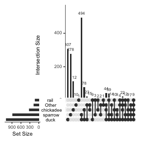

```r
plot(common_birds)
```

Or consider just the rare and interesting ones

```r
rare_birds<-mr_lump(bird_presence,n=-5,other_level="Common")
mtable(rare_birds)
```

```
##  poorwill redstart myna oriole cuckoo Common
##         9        4    1      8      1   1513
```

```r
mtable(rare_birds,rare_birds)
```

```
##          poorwill redstart myna oriole cuckoo Common
## poorwill        9        0    0      0      0      9
## redstart        0        4    0      3      0      4
## myna            0        0    1      0      0      1
## oriole          0        3    0      8      0      7
## cuckoo          0        0    0      0      1      1
## Common          9        4    1      7      1   1513
```

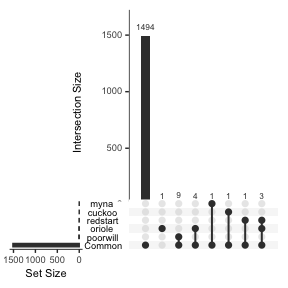

```r
plot(rare_birds,nsets=6)
```

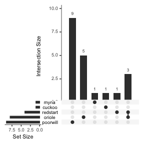

```r
plot(mr_drop(rare_birds,"Common"),nsets=5)
```